# Sales_Forecasting

## Liberaries Imported

```python
%matplotlib inline
from matplotlib import pyplot as plt
import numpy as np
import seaborn as sn
import pandas as pd
from pandas.plotting import register_matplotlib_converters
register_matplotlib_converters()
from pandas import *
import warnings
warnings.filterwarnings('ignore')
from statsmodels.tsa.seasonal import seasonal_decompose
from statsmodels.tsa.holtwinters import ExponentialSmoothing
from statsmodels.tsa.stattools import adfuller
from statsmodels.graphics.tsaplots import plot_acf, plot_pacf
from statsmodels.tsa.arima_model import ARIMA
from statsmodels.tsa.statespace.sarimax import SARIMAX
from sklearn.linear_model import LinearRegression
from sklearn.feature_selection import SelectKBest
from sklearn.feature_selection import f_regression
```

## .info()

This is used to print information about dataframe including dtype ,column and non-null values.

```python
sales_df = pd.read_csv('/content/sales_data_sample.csv', encoding='latin1')
type(sales_df)
sales_df
```

|  | ORDERNUMBER | QUANTITYORDERED | PRICEEACH | ORDERLINENUMBER | SALES | ORDERDATE | STATUS | QTR_ID | MONTH_ID | YEAR_ID | ... | ADDRESSLINE1 | ADDRESSLINE2 | CITY | STATE | POSTALCODE | COUNTRY | TERRITORY | CONTACTLASTNAME | CONTACTFIRSTNAME | DEALSIZE |
| --- | --- | --- | --- | --- | --- | --- | --- | --- | --- | --- | --- | --- | --- | --- | --- | --- | --- | --- | --- | --- | --- |
| 0 | 10107 | 30 | 95.70 | 2 | 2871.00 | 2/24/2003 0:00 | Shipped | 1 | 2 | 2003 | ... | 897 Long Airport Avenue | NaN | NYC | NY | 10022 | USA | NaN | Yu | Kwai | Small |
| 1 | 10121 | 34 | 81.35 | 5 | 2765.90 | 5/7/2003 0:00 | Shipped | 2 | 5 | 2003 | ... | 59 rue de l'Abbaye | NaN | Reims | NaN | 51100 | France | EMEA | Henriot | Paul | Small |
| 2 | 10134 | 41 | 94.74 | 2 | 3884.34 | 7/1/2003 0:00 | Shipped | 3 | 7 | 2003 | ... | 27 rue du Colonel Pierre Avia | NaN | Paris | NaN | 75508 | France | EMEA | Da Cunha | Daniel | Medium |
| 3 | 10145 | 45 | 83.26 | 6 | 3746.70 | 8/25/2003 0:00 | Shipped | 3 | 8 | 2003 | ... | 78934 Hillside Dr. | NaN | Pasadena | CA | 90003 | USA | NaN | Young | Julie | Medium |
| 4 | 10159 | 49 | 100.00 | 14 | 5205.27 | 10/10/2003 0:00 | Shipped | 4 | 10 | 2003 | ... | 7734 Strong St. | NaN | San Francisco | CA | NaN | USA | NaN | Brown | Julie | Medium |
| ... | ... | ... | ... | ... | ... | ... | ... | ... | ... | ... | ... | ... | ... | ... | ... | ... | ... | ... | ... | ... | ... |
| 2818 | 10350 | 20 | 100.00 | 15 | 2244.40 | 12/2/2004 0:00 | Shipped | 4 | 12 | 2004 | ... | C/ Moralzarzal, 86 | NaN | Madrid | NaN | 28034 | Spain | EMEA | Freyre | Diego | Small |
| 2819 | 10373 | 29 | 100.00 | 1 | 3978.51 | 1/31/2005 0:00 | Shipped | 1 | 1 | 2005 | ... | Torikatu 38 | NaN | Oulu | NaN | 90110 | Finland | EMEA | Koskitalo | Pirkko | Medium |
| 2820 | 10386 | 43 | 100.00 | 4 | 5417.57 | 3/1/2005 0:00 | Resolved | 1 | 3 | 2005 | ... | C/ Moralzarzal, 86 | NaN | Madrid | NaN | 28034 | Spain | EMEA | Freyre | Diego | Medium |
| 2821 | 10397 | 34 | 62.24 | 1 | 2116.16 | 3/28/2005 0:00 | Shipped | 1 | 3 | 2005 | ... | 1 rue Alsace-Lorraine | NaN | Toulouse | NaN | 31000 | France | EMEA | Roulet | Annette | Small |
| 2822 | 10414 | 47 | 65.52 | 9 | 3079.44 | 5/6/2005 0:00 | On Hold | 2 | 5 | 2005 | ... | 8616 Spinnaker Dr. | NaN | Boston | MA | 51003 | USA | NaN | Yoshido | Juri | Medium |

2823 rows × 25 columns

```python
sales_df.info()
```

```
<class 'pandas.core.frame.DataFrame'>
RangeIndex: 2823 entries, 0 to 2822
Data columns (total 25 columns):
 #   Column            Non-Null Count  Dtype
---  ------            --------------  -----
 0   ORDERNUMBER       2823 non-null   int64
 1   QUANTITYORDERED   2823 non-null   int64
 2   PRICEEACH         2823 non-null   float64
 3   ORDERLINENUMBER   2823 non-null   int64
 4   SALES             2823 non-null   float64
 5   ORDERDATE         2823 non-null   object
 6   STATUS            2823 non-null   object
 7   QTR_ID            2823 non-null   int64
 8   MONTH_ID          2823 non-null   int64
 9   YEAR_ID           2823 non-null   int64
```

[output cut: 17 more lines]

#### .describe()

Descriptive stats include those that summarise central tendancy,dispersion and shape of dataset excluding NaN values.

```python
sales_df.describe()
```

|  | ORDERNUMBER | QUANTITYORDERED | PRICEEACH | ORDERLINENUMBER | SALES | QTR_ID | MONTH_ID | YEAR_ID | MSRP |
| --- | --- | --- | --- | --- | --- | --- | --- | --- | --- |
| count | 2823.000000 | 2823.000000 | 2823.000000 | 2823.000000 | 2823.000000 | 2823.000000 | 2823.000000 | 2823.00000 | 2823.000000 |
| mean | 10258.725115 | 35.092809 | 83.658544 | 6.466171 | 3553.889072 | 2.717676 | 7.092455 | 2003.81509 | 100.715551 |
| std | 92.085478 | 9.741443 | 20.174277 | 4.225841 | 1841.865106 | 1.203878 | 3.656633 | 0.69967 | 40.187912 |
| min | 10100.000000 | 6.000000 | 26.880000 | 1.000000 | 482.130000 | 1.000000 | 1.000000 | 2003.00000 | 33.000000 |
| 25% | 10180.000000 | 27.000000 | 68.860000 | 3.000000 | 2203.430000 | 2.000000 | 4.000000 | 2003.00000 | 68.000000 |
| 50% | 10262.000000 | 35.000000 | 95.700000 | 6.000000 | 3184.800000 | 3.000000 | 8.000000 | 2004.00000 | 99.000000 |
| 75% | 10333.500000 | 43.000000 | 100.000000 | 9.000000 | 4508.000000 | 4.000000 | 11.000000 | 2004.00000 | 124.000000 |
| max | 10425.000000 | 97.000000 | 100.000000 | 18.000000 | 14082.800000 | 4.000000 | 12.000000 | 2005.00000 | 214.000000 |

```python
sales_df.columns
```

```
Index(['ORDERNUMBER', 'QUANTITYORDERED', 'PRICEEACH', 'ORDERLINENUMBER',
       'SALES', 'ORDERDATE', 'STATUS', 'QTR_ID', 'MONTH_ID', 'YEAR_ID',
       'PRODUCTLINE', 'MSRP', 'PRODUCTCODE', 'CUSTOMERNAME', 'PHONE',
       'ADDRESSLINE1', 'ADDRESSLINE2', 'CITY', 'STATE', 'POSTALCODE',
       'COUNTRY', 'TERRITORY', 'CONTACTLASTNAME', 'CONTACTFIRSTNAME',
       'DEALSIZE'],
      dtype='object')
```

```python
sales_df.shape
```

```
(2823, 25)
```

```python
sales_df.COUNTRY.unique()
```

```
array(['USA', 'France', 'Norway', 'Australia', 'Finland', 'Austria', 'UK',
       'Spain', 'Sweden', 'Singapore', 'Canada', 'Japan', 'Italy',
       'Denmark', 'Belgium', 'Philippines', 'Germany', 'Switzerland',
       'Ireland'], dtype=object)
```

### SALES

```python
df1=sales_df[['STATUS','YEAR_ID','SALES']]
df1.head()
```

|  | STATUS | YEAR_ID | SALES |
| --- | --- | --- | --- |
| 0 | Shipped | 2003 | 2871.00 |
| 1 | Shipped | 2003 | 2765.90 |
| 2 | Shipped | 2003 | 3884.34 |
| 3 | Shipped | 2003 | 3746.70 |
| 4 | Shipped | 2003 | 5205.27 |

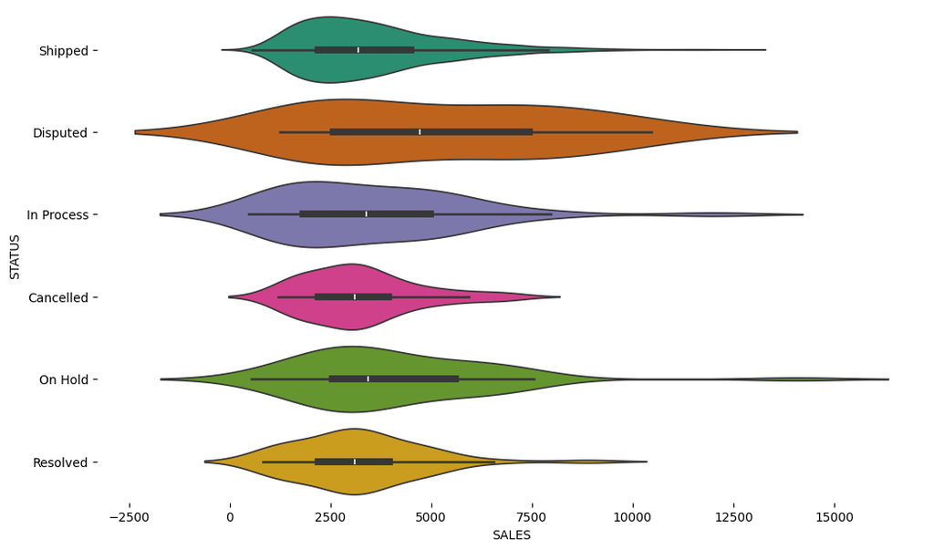

```python
from matplotlib import pyplot as plt
import seaborn as sns
figsize = (12, 1.2 * len(df1['STATUS'].unique()))
plt.figure(figsize=figsize)
sns.violinplot(df1, x='SALES', y='STATUS', inner='box', palette='Dark2')
sns.despine(top=True, right=True, bottom=True, left=True)
```

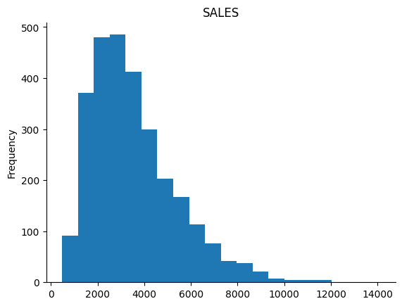

```python
from matplotlib import pyplot as plt
df1['SALES'].plot(kind='hist', bins=20, title='SALES')
plt.gca().spines[['top', 'right',]].set_visible(False)
```

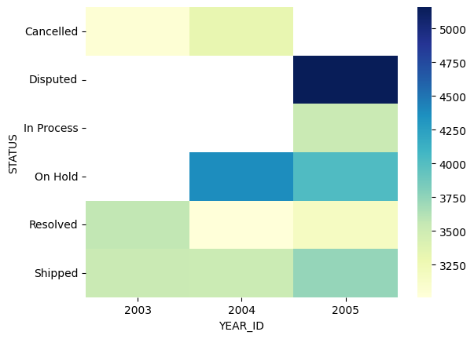

```python
heatmap_data=pd.pivot_table(df1,values='SALES',index=['STATUS'],columns='YEAR_ID')
sns.heatmap(heatmap_data,cmap='YlGnBu')
```

### DEALSIZE

In this we will check which DEALSIZE has maximum sales in each year with help of barplot.

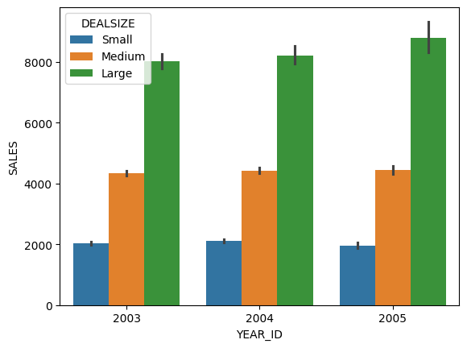

```python
sns.barplot(x='YEAR_ID',y='SALES',hue='DEALSIZE',data=sales_df)
```

- From the graph we can say DEALSIZE 'large' has maximum sales in each year.  
  further maximum sale of 'large' DEALSIZE in 2005.

### ORDER PER YEAR

In this we will check in which year orders is maximum with help of pie chart.

```python
sales_df.YEAR_ID.nunique()
```

```
3
```

```python
sales_report = sales_df.YEAR_ID.value_counts()
sales_report
```

```
YEAR_ID
2004    1345
2003    1000
2005     478
Name: count, dtype: int64
```

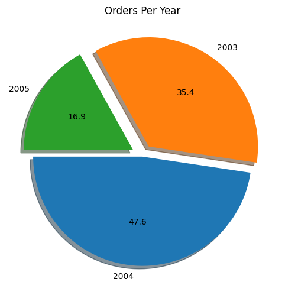

```python
plt.figure(figsize=(12,6))
plt.title("Orders Per Year")
plt.pie(sales_report,labels=sales_report.index,autopct='%1.1f',shadow=True,explode=(0.01,0.1,0.1),startangle=180);
```

We can see that in 2004 orders is maximum.

### COUNTRY

In this we will check top 10 countries having maximum no of orders.

```python
top_countries = pd.DataFrame(data={'Count':sales_df.COUNTRY.value_counts().head(10)})
top_countries = pd.DataFrame(top_countries).rename_axis('COUNTRY', axis=1)
top_countries
```

| COUNTRY | Count |
| --- | --- |
| USA | 1004 |
| Spain | 342 |
| France | 314 |
| Australia | 185 |
| UK | 144 |
| Italy | 113 |
| Finland | 92 |
| Norway | 85 |
| Singapore | 79 |
| Canada | 70 |

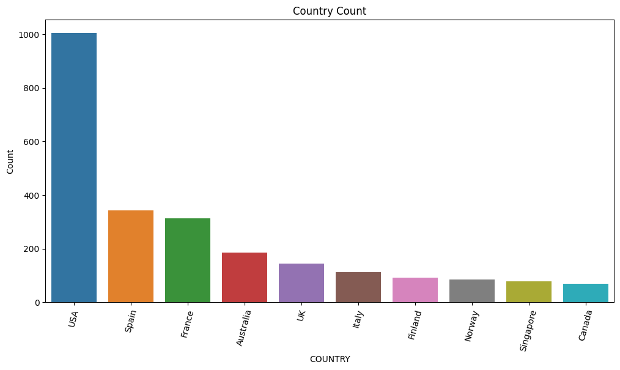

```python
plt.figure(figsize=(12,6))
plt.xticks(rotation=75)
plt.title("Country Count")
sns.barplot(x = top_countries.index, y = top_countries.Count, hue=top_countries.index);
```

We can clearly see that maximum order came from USA followed by Spain.

## STATUS

Here we will see the status of order with help of pie chart.

```python
status_counts = sales_df.STATUS.value_counts()
status_counts
```

```
Shipped       2617
Cancelled       60
Resolved        47
On Hold         44
In Process      41
Disputed        14
Name: STATUS, dtype: int64
```

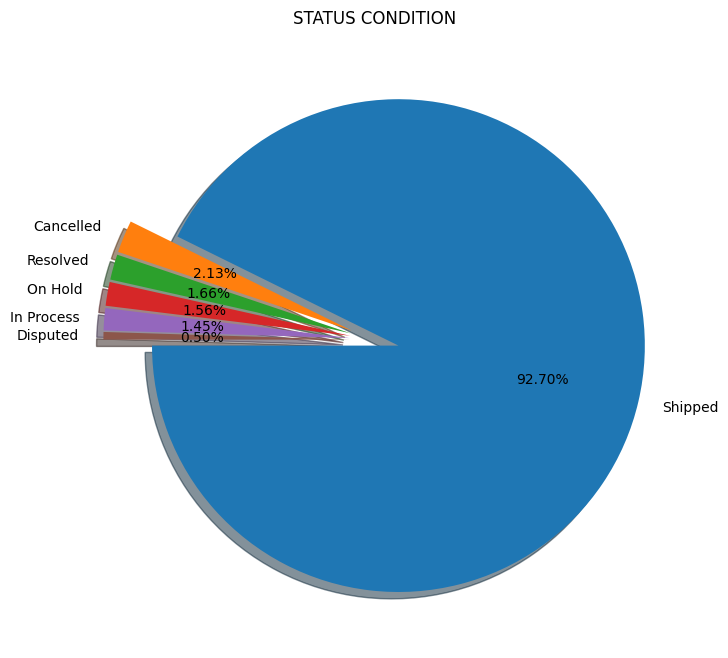

```python
plt.figure(figsize=(8,8))
plt.title('STATUS CONDITION')
plt.pie(status_counts, labels=status_counts.index, autopct='%1.2f%%',shadow=True,explode=(0.1,0.1,0.1,0.1,0.1,0.1), startangle=180);
```

From the pie chart we can say that status of maximum order is 'Shipped' and minimum is 'Disputed'.

### 1. Which DEALSIZE have highest proportion when top 20 orders arrange according to QUANTITYORDERED ?

```python
top_df = sales_df.sort_values('QUANTITYORDERED',ascending=False).head(20)
top_df[['DEALSIZE', 'QUANTITYORDERED']]
```

|  | DEALSIZE | QUANTITYORDERED |
| --- | --- | --- |
| 418 | Large | 97 |
| 2586 | Large | 85 |
| 2689 | Large | 77 |
| 1995 | Large | 76 |
| 1714 | Large | 76 |
| 598 | Large | 76 |
| 1666 | Large | 70 |
| 1996 | Large | 70 |
| 25 | Large | 66 |
| 104 | Large | 66 |
| 1413 | Medium | 66 |
| 264 | Large | 66 |
| 1288 | Medium | 66 |
| 1188 | Large | 65 |
| 2022 | Medium | 64 |
| 1514 | Small | 64 |
| 131 | Large | 64 |
| 2325 | Medium | 62 |
| 1562 | Small | 61 |
| 473 | Large | 61 |

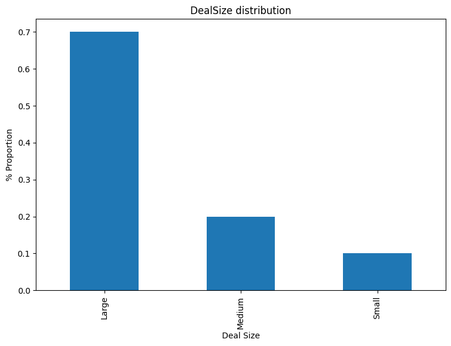

```python
plt.figure(figsize=(9,6))
top_df['DEALSIZE'].value_counts(normalize = True).plot(kind = 'bar')
plt.title('DealSize distribution')
plt.xlabel('Deal Size')
plt.ylabel('% Proportion')
plt.show()
```

From the graph we get to know that Large DEALSIZE has highest proportion.

### 2. From the graph show the frequency of QUANTITYORDERED and tell when it is high.

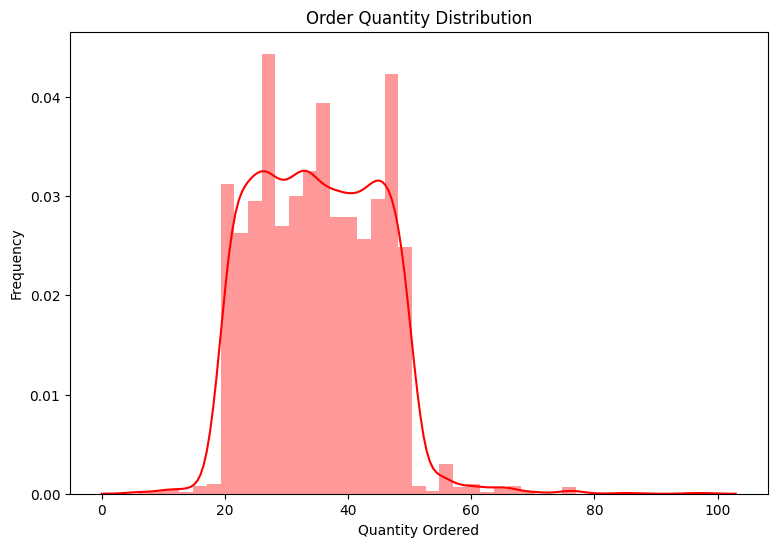

```python
plt.figure(figsize=(9,6))
sns.distplot(sales_df['QUANTITYORDERED'],color='r')
plt.title('Order Quantity Distribution')
plt.xlabel('Quantity Ordered')
plt.ylabel('Frequency')
plt.show()
```

### 3. In which month customers are highly active?

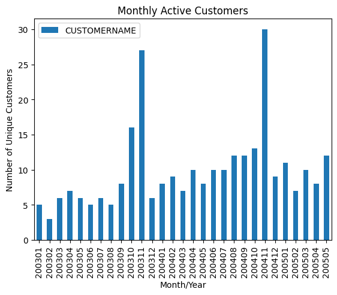

```python
sales_df['YEAR_MONTH'] = sales_df['YEAR_ID'].map(str)+sales_df['MONTH_ID'].map(str).map(lambda x: x.rjust(2,'0'))
monthly_active = sales_df.groupby(['YEAR_MONTH'])['CUSTOMERNAME'].nunique().reset_index()
monthly_active.plot(kind='bar',x='YEAR_MONTH',y='CUSTOMERNAME')
plt.title('Monthly Active Customers')
plt.xlabel('Month/Year')
plt.ylabel('Number of Unique Customers')
plt.xticks(rotation=90)
plt.show()
```

As expected, customers are highly active during the months of November and October.  
The number of active customers increased from 2003 to 2004 which indicates that the  
company is successful in retention/acquisition of old/new customers.

### 4. Show where the monthly revenue growth rate is high.

```python
month_revenue = sales_df.groupby(['YEAR_ID','MONTH_ID'])['SALES'].sum().reset_index()
month_revenue
```

|  | YEAR_ID | MONTH_ID | SALES |
| --- | --- | --- | --- |
| 0 | 2003 | 1 | 129753.60 |
| 1 | 2003 | 2 | 140836.19 |
| 2 | 2003 | 3 | 174504.90 |
| 3 | 2003 | 4 | 201609.55 |
| 4 | 2003 | 5 | 192673.11 |
| 5 | 2003 | 6 | 168082.56 |
| 6 | 2003 | 7 | 187731.88 |
| 7 | 2003 | 8 | 197809.30 |
| 8 | 2003 | 9 | 263973.36 |
| 9 | 2003 | 10 | 568290.97 |
| 10 | 2003 | 11 | 1029837.66 |
| 11 | 2003 | 12 | 261876.46 |
| 12 | 2004 | 1 | 316577.42 |
| 13 | 2004 | 2 | 311419.53 |
| 14 | 2004 | 3 | 205733.73 |
| 15 | 2004 | 4 | 206148.12 |
| 16 | 2004 | 5 | 273438.39 |
| 17 | 2004 | 6 | 286674.22 |
| 18 | 2004 | 7 | 327144.09 |
| 19 | 2004 | 8 | 461501.27 |
| 20 | 2004 | 9 | 320750.91 |
| 21 | 2004 | 10 | 552924.25 |
| 22 | 2004 | 11 | 1089048.01 |
| 23 | 2004 | 12 | 372802.66 |
| 24 | 2005 | 1 | 339543.42 |
| 25 | 2005 | 2 | 358186.18 |
| 26 | 2005 | 3 | 374262.76 |
| 27 | 2005 | 4 | 261633.29 |
| 28 | 2005 | 5 | 457861.06 |

```python
month_revenue['MONTHLY GROWTH'] = month_revenue['SALES'].pct_change()
month_revenue.head()
```

|  | YEAR_ID | MONTH_ID | SALES | MONTHLY GROWTH |
| --- | --- | --- | --- | --- |
| 0 | 2003 | 1 | 129753.60 | NaN |
| 1 | 2003 | 2 | 140836.19 | 0.085413 |
| 2 | 2003 | 3 | 174504.90 | 0.239063 |
| 3 | 2003 | 4 | 201609.55 | 0.155323 |
| 4 | 2003 | 5 | 192673.11 | -0.044325 |

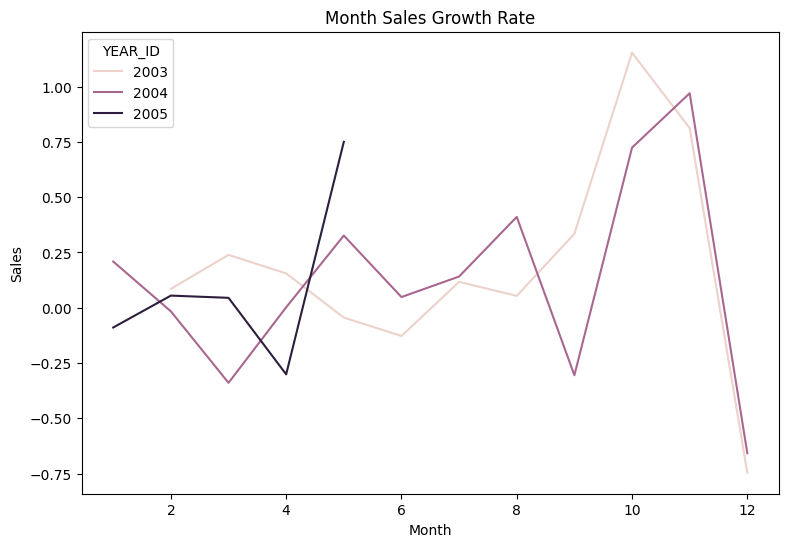

```python
plt.figure(figsize=(9,6))
sns.lineplot(x="MONTH_ID", y="MONTHLY GROWTH",hue="YEAR_ID", data=month_revenue)
plt.xlabel('Month')
plt.ylabel('Sales')
plt.title('Month Sales Growth Rate')
plt.show()
```

Apart from expected high/low growth rates during the seasonal months, there is high growth rate from Apr 2005 to May 2005.

### 5. In which countries the sales are the highest ? Consider countries with more than 50 responses only.

First we will use 'groupby' data frame method to aggregate the rows for each country.

```python
countries_df = sales_df.groupby('COUNTRY')[['SALES']].mean().sort_values('SALES',ascending=False)
```

Now we will filter the result to get countries of only those  
which have more than 50 responses.

```python
highest_sale = countries_df.loc[sales_df.COUNTRY.value_counts()>50].head(19)

highest_sale
```

| COUNTRY | SALES |
| --- | --- |
| Denmark | 3899.002381 |
| Sweden | 3684.459825 |
| Austria | 3673.864182 |
| Singapore | 3651.752025 |
| Japan | 3618.611731 |
| Norway | 3617.220000 |
| USA | 3613.528715 |
| Finland | 3582.412065 |
| Germany | 3556.001452 |
| Spain | 3554.640117 |
| France | 3537.950701 |
| Australia | 3408.773514 |
| UK | 3325.558750 |
| Italy | 3315.701858 |
| Canada | 3201.122286 |

## Sales Prediction

```python
df = pd.read_csv('/content/train.csv')
df
```

|  | date | store | item | sales |
| --- | --- | --- | --- | --- |
| 0 | 2013-01-01 | 1 | 1 | 13 |
| 1 | 2013-01-02 | 1 | 1 | 11 |
| 2 | 2013-01-03 | 1 | 1 | 14 |
| 3 | 2013-01-04 | 1 | 1 | 13 |
| 4 | 2013-01-05 | 1 | 1 | 10 |
| ... | ... | ... | ... | ... |
| 912995 | 2017-12-27 | 10 | 50 | 63 |
| 912996 | 2017-12-28 | 10 | 50 | 59 |
| 912997 | 2017-12-29 | 10 | 50 | 74 |
| 912998 | 2017-12-30 | 10 | 50 | 62 |
| 912999 | 2017-12-31 | 10 | 50 | 82 |

913000 rows × 4 columns

```python
df.isnull().sum()
```

```
date     0
store    0
item     0
sales    0
dtype: int64
```

```python
# Filter records for store 1 and item 1 -> to be able to scale to other items in the future
df = df[df['store'] == 1]
df = df[df['item'] == 1]

df['date'] = pd.to_datetime(df['date'], format='%Y-%m-%d') # convert date column to datatime object

# Create Date-related Features to be used for EDA and Supervised ML: Regression
df['year'] = df['date'].dt.year
df['month'] = df['date'].dt.month
df['day'] = df['date'].dt.day
df['weekday'] = df['date'].dt.weekday
df['weekday'] = np.where(df.weekday == 0, 7, df.weekday)

# Split the series to predict the last 3 months of 2017
temp_df = df.set_index('date')
train_df = temp_df.loc[:'2017-09-30'].reset_index(drop=False)
test_df = temp_df.loc['2017-10-01':].reset_index(drop=False)

train_df.head()
```

|  | date | store | item | sales | year | month | day | weekday |
| --- | --- | --- | --- | --- | --- | --- | --- | --- |
| 0 | 2013-01-01 | 1 | 1 | 13 | 2013 | 1 | 1 | 1 |
| 1 | 2013-01-02 | 1 | 1 | 11 | 2013 | 1 | 2 | 2 |
| 2 | 2013-01-03 | 1 | 1 | 14 | 2013 | 1 | 3 | 3 |
| 3 | 2013-01-04 | 1 | 1 | 13 | 2013 | 1 | 4 | 4 |
| 4 | 2013-01-05 | 1 | 1 | 10 | 2013 | 1 | 5 | 5 |

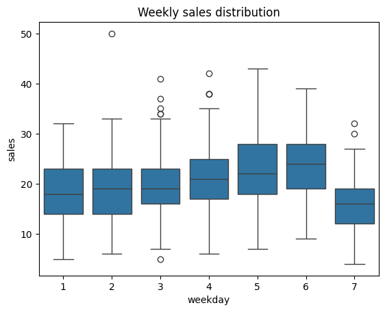

```python
plot = sn.boxplot(x='weekday', y='sales', data=df)
_ = plot.set(title='Weekly sales distribution')
```

```python
# subtract 1 year from test data
dates = (test_df['date'] - np.timedelta64(1, 'Y') + \
        np.timedelta64(1, 'D')).values.astype('datetime64[D]')
seasonal_naive_sales = train_df[train_df['date'].isin(dates)]['sales']

# make a copy of the test_df and make naive predictions for the last 3 months of 2017
sn_pred_df = test_df.copy().drop('sales', axis=1)
sn_pred_df['seasonal_naive_sales'] = pd.DataFrame(seasonal_naive_sales).set_index(test_df.index)
sn_pred_df.head()
```

|  | date | store | item | year | month | day | weekday | seasonal_naive_sales |
| --- | --- | --- | --- | --- | --- | --- | --- | --- |
| 0 | 2017-10-01 | 1 | 1 | 2017 | 10 | 1 | 6 | 26 |
| 1 | 2017-10-02 | 1 | 1 | 2017 | 10 | 2 | 7 | 20 |
| 2 | 2017-10-03 | 1 | 1 | 2017 | 10 | 3 | 1 | 28 |
| 3 | 2017-10-04 | 1 | 1 | 2017 | 10 | 4 | 2 | 17 |
| 4 | 2017-10-05 | 1 | 1 | 2017 | 10 | 5 | 3 | 22 |

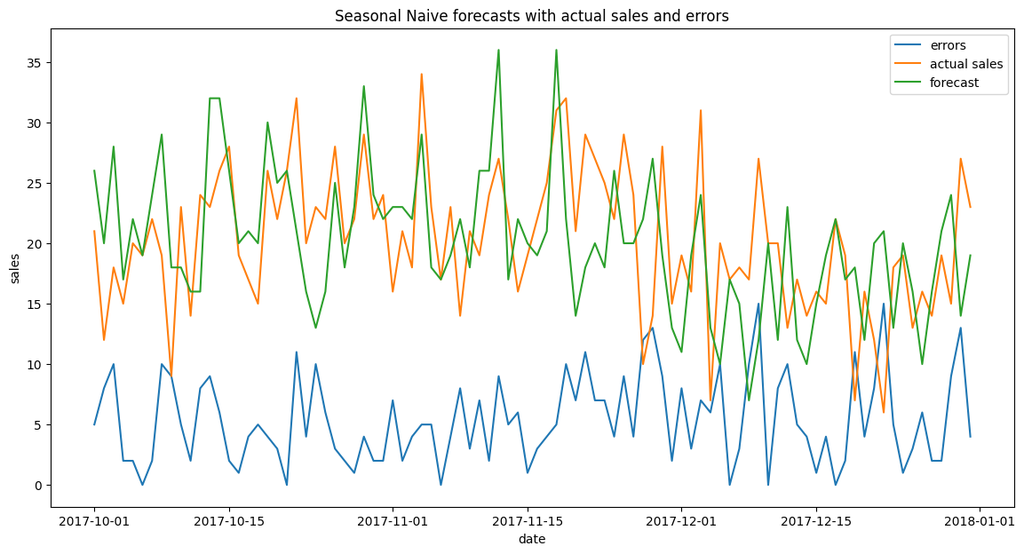

| model | total_sales | total_sn_pred_sales | overall_error | MAE | RMSE | MAPE |
| --- | --- | --- | --- | --- | --- | --- |
| Seasonal Naive | 1861 | 1851 | 10 | 5.391304 | 6.507521 | 26.652337 |

```python
errors_df = pd.merge(test_df, sn_pred_df, on='date')
errors_df = errors_df[['date', 'sales', 'seasonal_naive_sales']]
errors_df = pd.merge(test_df, sn_pred_df, on='date')
errors_df = errors_df[['date', 'sales', 'seasonal_naive_sales']]
errors_df['errors'] = test_df['sales'] - sn_pred_df['seasonal_naive_sales']
errors_df.insert(0, 'model', 'Seasonal Naive')

def mae(err):
    return np.mean(np.abs(err))

def rmse(err):
    return np.sqrt(np.mean(err ** 2))

def mape(err, sales=errors_df['sales']):
    return np.sum(np.abs(err))/np.sum(sales) * 100

result_df = errors_df.groupby('model').agg(total_sales=('sales', 'sum'),
                                           total_sn_pred_sales=('seasonal_naive_sales', 'sum'),
                                           overall_error=('errors', 'sum'),
                                           MAE=('errors', mae),
                                           RMSE=('errors', rmse),
                                           MAPE=('errors', mape))


plt.figure(figsize=(14,7))
plt.plot(errors_df['date'], np.abs(errors_df['errors']), label='errors')
plt.plot(errors_df['date'], errors_df['sales'], label='actual sales')
plt.plot(errors_df['date'], errors_df['seasonal_naive_sales'], label='forecast')
plt.legend(loc='best')
plt.xlabel('date')
plt.ylabel('sales')
plt.title('Seasonal Naive forecasts with actual sales and errors')
plt.show()

result_df
```

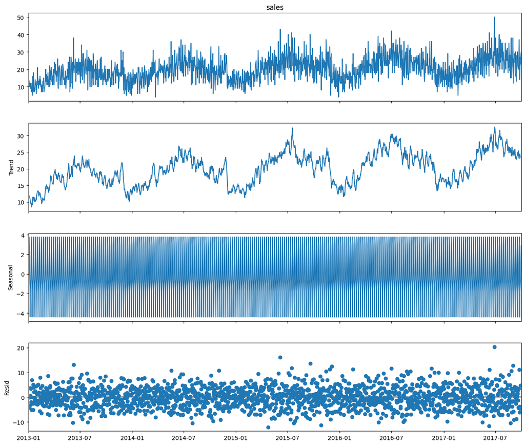

```python
ts_decomp_df = train_df.set_index('date') # set date as index
ts_decomp_df['sales'] = ts_decomp_df['sales'].astype(float)
result = seasonal_decompose(ts_decomp_df['sales'], model='additive')
fig = plt.figure()
fig = result.plot()
fig.set_size_inches(14, 12)
```

```python
hw_train_df = train_df[['date', 'sales']].set_index('date')
hw_test_df = test_df[['date', 'sales']].set_index('date')

# Apply Triple Exponential Smoothing

hw_model_1 = ExponentialSmoothing(hw_train_df, trend='add', seasonal='add', seasonal_periods=12)
hw_fit_1 = hw_model_1.fit(remove_bias=False)
pred_fit_1 = pd.Series(hw_fit_1.predict(start=hw_test_df.index[0], end=hw_test_df.index[-1]),
                       name='pred_sales').reset_index()

hw_model_2 = ExponentialSmoothing(hw_train_df, trend='add', seasonal='add', seasonal_periods=12, damped=True)
hw_fit_2 = hw_model_2.fit(remove_bias=False)
pred_fit_2 = pd.Series(hw_fit_2.predict(start=hw_test_df.index[0], end=hw_test_df.index[-1]),
                       name='pred_sales').reset_index()
print('Forecasts made, ready for evaluation')
```

```
Forecasts made, ready for evaluation
```

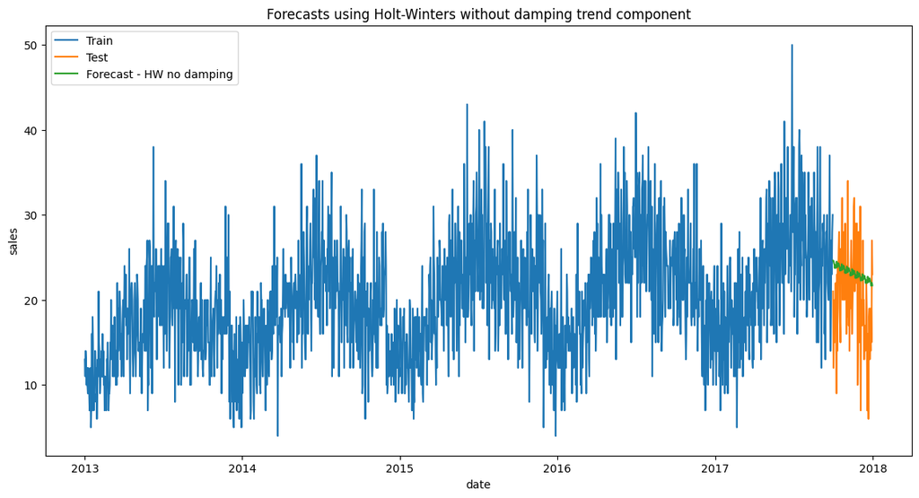

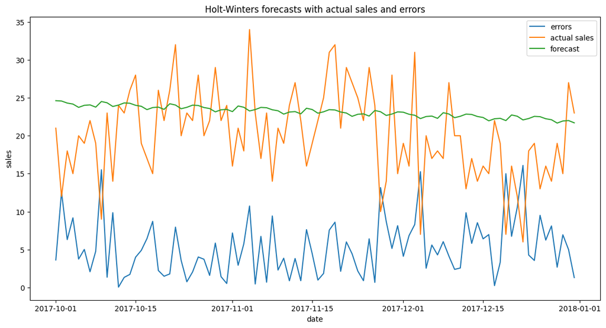

| model | total_sales | total_pred_sales | holt_winters_overall_error | MAE | RMSE | MAPE |
| --- | --- | --- | --- | --- | --- | --- |
| Holt-Winters | 1861 | 2132.536302 | -271.536302 | 5.235092 | 6.430953 | 25.880088 |

```python
# Merge predictions and actual sales into one df
errors_df_hw = pd.merge(test_df, pred_fit_1, left_on='date', right_on='index')
errors_df_hw = errors_df_hw[['date', 'sales', 'pred_sales']]
errors_df_hw['errors'] = errors_df_hw.sales - errors_df_hw.pred_sales
errors_df_hw.insert(0, 'model', 'Holt-Winters')


# Evaluate the predictions for Holt-Winters without damping trend component
plt.figure(figsize=(14,7))
plt.plot(train_df['date'], train_df['sales'], label='Train')
plt.plot(test_df['date'], test_df['sales'], label='Test')
plt.plot(errors_df_hw['date'], errors_df_hw['pred_sales'], label='Forecast - HW no damping')
plt.legend(loc='best')
plt.xlabel('date')
plt.ylabel('sales')
plt.title('Forecasts using Holt-Winters without damping trend component')
plt.show()


plt.figure(figsize=(14,7))
plt.plot(errors_df_hw['date'], np.abs(errors_df_hw['errors']), label='errors')
plt.plot(errors_df_hw['date'], errors_df_hw['sales'], label='actual sales')
plt.plot(errors_df_hw['date'], errors_df_hw['pred_sales'], label='forecast')
plt.legend(loc='best')
plt.xlabel('date')
plt.ylabel('sales')
plt.title('Holt-Winters forecasts with actual sales and errors')
plt.show()

result_df_hw = errors_df_hw.groupby('model').agg(total_sales=('sales', 'sum'),
                                          total_pred_sales=('pred_sales', 'sum'),
                                          holt_winters_overall_error=('errors', 'sum'),
                                          MAE=('errors', mae),
                                          RMSE=('errors', rmse),
                                          MAPE=('errors', mape))
result_df_hw
```

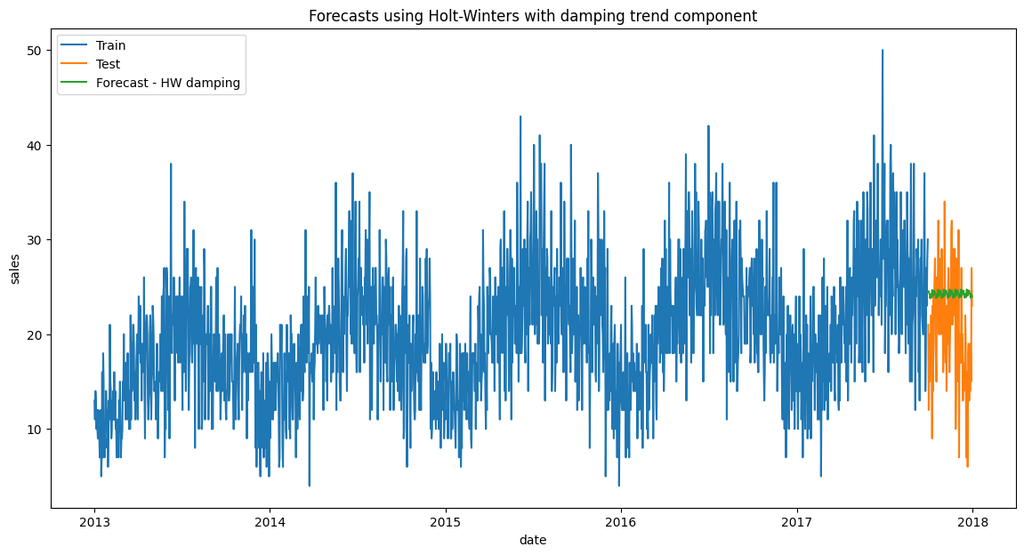

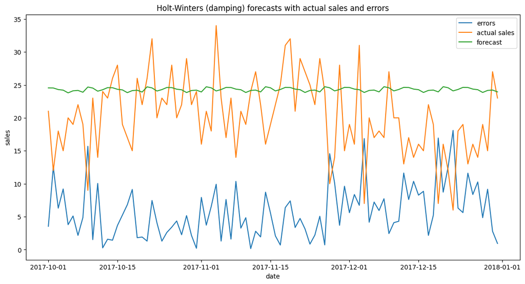

| model | total_sales | total_pred_sales | holt_winters_overall_error | MAE | RMSE | MAPE |
| --- | --- | --- | --- | --- | --- | --- |
| Holt-Winters-Damped | 1861 | 2234.806611 | -373.806611 | 5.820579 | 7.102234 | 28.774489 |

```python
# Merge predictions and actual sales into one df
errors_df_hwd = pd.merge(test_df, pred_fit_2, left_on='date', right_on='index')
errors_df_hwd = errors_df_hwd[['date', 'sales','pred_sales']]
errors_df_hwd['errors'] = errors_df_hwd.sales - errors_df_hwd.pred_sales
errors_df_hwd.insert(0, 'model', 'Holt-Winters-Damped')


# Evaluate the predictions for Holt-Winters without damping trend component
plt.figure(figsize=(14,7))
plt.plot(train_df['date'], train_df['sales'], label='Train')
plt.plot(test_df['date'], test_df['sales'], label='Test')
plt.plot(errors_df_hwd['date'], errors_df_hwd['pred_sales'], label='Forecast - HW damping')
plt.legend(loc='best')
plt.xlabel('date')
plt.ylabel('sales')
plt.title('Forecasts using Holt-Winters with damping trend component')
plt.show()

plt.figure(figsize=(14,7))
plt.plot(errors_df_hwd['date'], np.abs(errors_df_hwd['errors']), label='errors')
plt.plot(errors_df_hwd['date'], errors_df_hwd['sales'], label='actual sales')
plt.plot(errors_df_hwd['date'], errors_df_hwd['pred_sales'], label='forecast')
plt.legend(loc='best')
plt.xlabel('date')
plt.ylabel('sales')
plt.title('Holt-Winters (damping) forecasts with actual sales and errors')
plt.show()

result_df_hwd = errors_df_hwd.groupby('model').agg(total_sales=('sales', 'sum'),
                                          total_pred_sales=('pred_sales', 'sum'),
                                          holt_winters_overall_error=('errors', 'sum'),
                                          MAE=('errors', mae),
                                          RMSE=('errors', rmse),
                                          MAPE=('errors', mape))
result_df_hwd
```

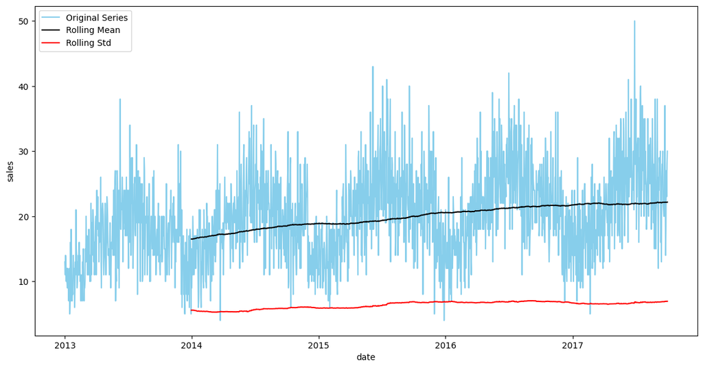

```
Test statistic = -2.937
P-value = 0.041
Critical values :
	1%: -3.434179908502461 - The data is not stationary with 99% confidence
	5%: -2.863231689892687 - The data is  stationary with 95% confidence
	10%: -2.567670609760268 - The data is  stationary with 90% confidence
```

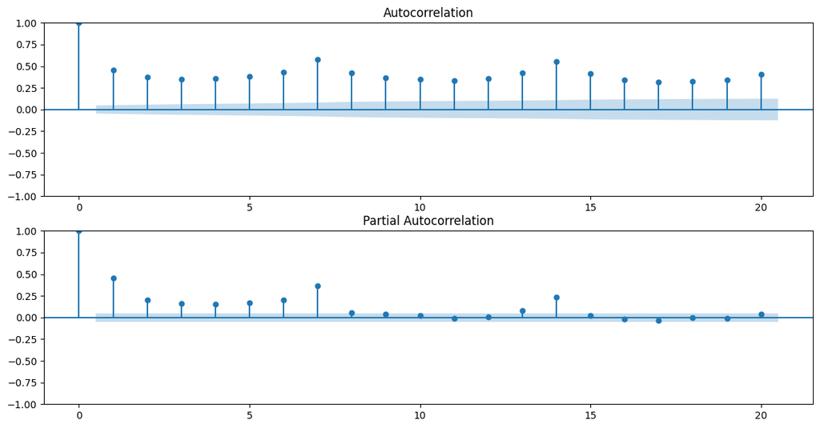

```python
arima_df = train_df[['date', 'sales']].set_index('date')
arima_test_df = test_df[['date', 'sales']].set_index('date')

def test_stationarity(timeseries):
    # Plotting rolling statistics
    rollmean = timeseries.rolling(window=365).mean()
    rollstd = timeseries.rolling(window=365).std()

    plt.figure(figsize=(14,7))
    plt.plot(timeseries, color='skyblue', label='Original Series')
    plt.plot(rollmean, color='black', label='Rolling Mean')
    plt.plot(rollstd, color='red', label='Rolling Std')
    plt.legend(loc='best')
    plt.xlabel('date')
    plt.ylabel('sales')
    plt.show()

    # Augmented Dickey-Fuller Test
    adfuller_test = adfuller(timeseries, autolag='AIC')
    print("Test statistic = {:.3f}".format(adfuller_test[0]))
    print("P-value = {:.3f}".format(adfuller_test[1]))
    print("Critical values :")

    for key, value in adfuller_test[4].items():
        print("\t{}: {} - The data is {} stationary with {}% confidence"
              .format(key, value, '' if adfuller_test[0] < value else 'not', 100-int(key[:-1])))

    # Autocorrelation Plots
    fig, ax = plt.subplots(2, figsize=(14,7))
    ax[0] = plot_acf(timeseries, ax=ax[0], lags=20)
    ax[1] = plot_pacf(timeseries, ax=ax[1], lags=20)

test_stationarity(arima_df.sales)
```

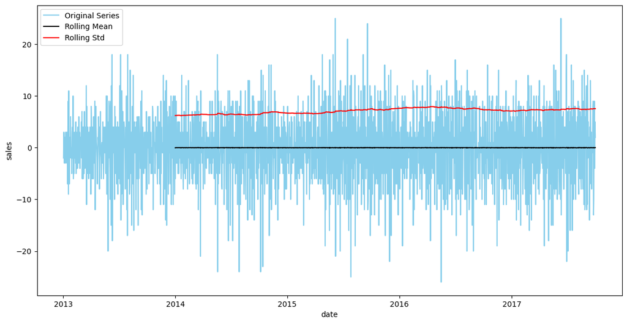

```
Test statistic = -12.326
P-value = 0.000
Critical values :
	1%: -3.434179908502461 - The data is  stationary with 99% confidence
	5%: -2.863231689892687 - The data is  stationary with 95% confidence
	10%: -2.567670609760268 - The data is  stationary with 90% confidence
```

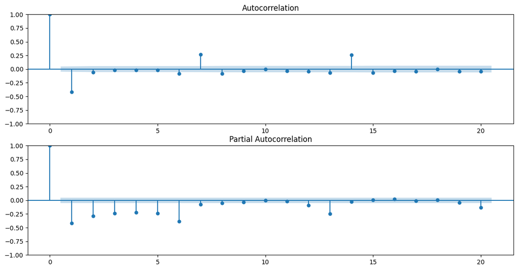

```python
first_difference = arima_df.sales - arima_df.sales.shift(1)
first_difference = pd.DataFrame(first_difference.dropna(inplace=False))
# Check for stationarity after differencing
test_stationarity(first_difference.sales)
```

```python
from statsmodels.tsa.arima.model import ARIMA
arima_model61 = ARIMA(arima_df.sales, order=(6,1,1)).fit()
print(arima_model61.summary())
```

```
                               SARIMAX Results
==============================================================================
Dep. Variable:                  sales   No. Observations:                 1734
Model:                 ARIMA(6, 1, 1)   Log Likelihood               -5306.648
Date:                Tue, 23 Apr 2024   AIC                          10629.296
Time:                        06:52:04   BIC                          10672.957
Sample:                    01-01-2013   HQIC                         10645.443
                         - 09-30-2017
Covariance Type:                  opg
==============================================================================
                 coef    std err          z      P>|z|      [0.025      0.975]
------------------------------------------------------------------------------
ar.L1         -0.6039      0.051    -11.899      0.000      -0.703      -0.504
ar.L2         -0.6032      0.040    -15.019      0.000      -0.682      -0.524
ar.L3         -0.5652      0.037    -15.248      0.000      -0.638      -0.493
ar.L4         -0.5145      0.035    -14.876      0.000      -0.582      -0.447
ar.L5         -0.4386      0.031    -14.131      0.000      -0.499      -0.378
ar.L6         -0.3356      0.027    -12.519      0.000      -0.388      -0.283
ma.L1         -0.2493      0.055     -4.535      0.000      -0.357      -0.142
sigma2        26.7129      0.824     32.414      0.000      25.098      28.328
===================================================================================
Ljung-Box (L1) (Q):                   0.02   Jarque-Bera (JB):                18.88
Prob(Q):                              0.88   Prob(JB):                         0.00
Heteroskedasticity (H):               1.40   Skew:                             0.13
Prob(H) (two-sided):                  0.00   Kurtosis:                         3.44
===================================================================================

Warnings:
[1] Covariance matrix calculated using the outer product of gradients (complex-step).
```

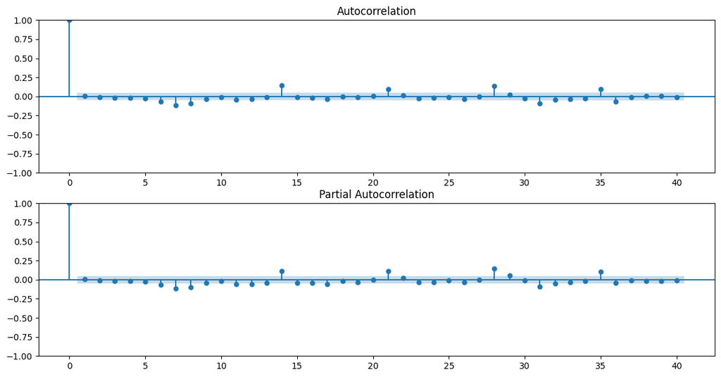

```python
residuals = arima_model61.resid
# Checking for seasonality
fig, ax = plt.subplots(2, figsize=(14,7))
ax[0] = plot_acf(residuals, ax=ax[0], lags=40)
ax[1] = plot_pacf(residuals, ax=ax[1], lags=40)
```

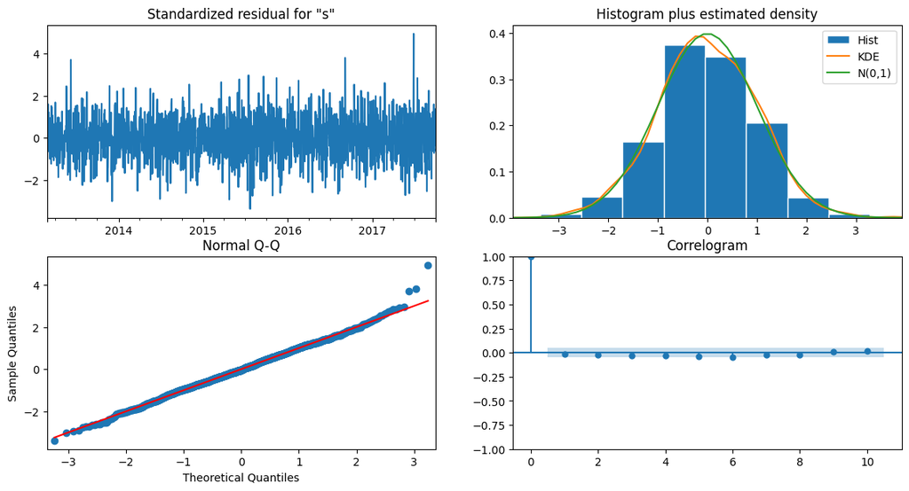

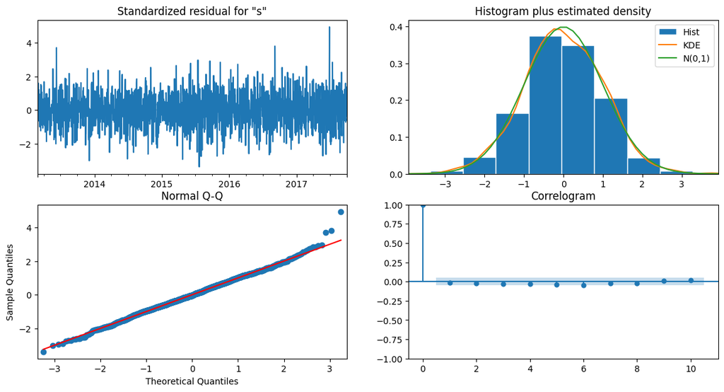

```python
# fit the model
sarima_model = SARIMAX(arima_df.sales, order=(6, 1, 0), seasonal_order=(6, 1, 0, 7),
                       enforce_invertibility=False, enforce_stationarity=False)
sarima_fit = sarima_model.fit()
arima_test_df['pred_sales'] = sarima_fit.predict(start=arima_test_df.index[0],
                                                 end=arima_test_df.index[-1], dynamic= True)
plot = sarima_fit.plot_diagnostics(figsize=(14,7))
plot
```

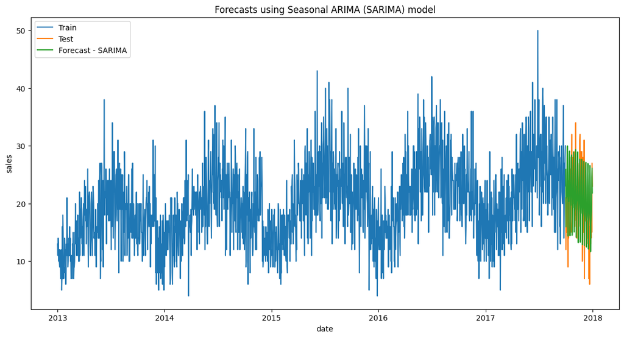

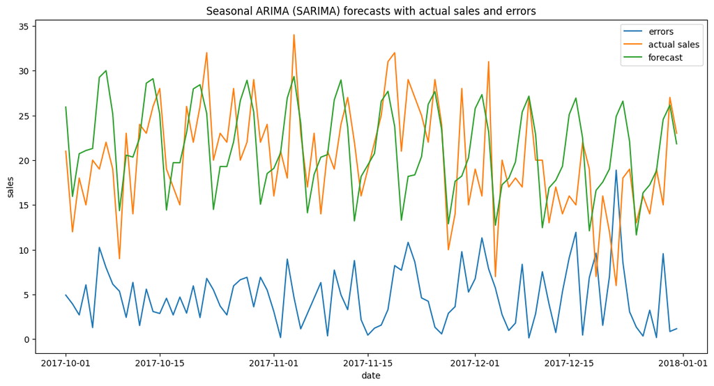

| model | total_sales | total_pred_sales | SARIMA_overall_error | MAE | RMSE | MAPE |
| --- | --- | --- | --- | --- | --- | --- |
| SARIMA | 1861 | 1973.197447 | -112.197447 | 4.799933 | 5.839147 | 23.728846 |

```python
# eval
arima_test_df['errors'] = arima_test_df.sales - arima_test_df.pred_sales
arima_test_df.insert(0, 'model', 'SARIMA')

# Evaluate the predictions for Seasonal ARIMA model
plt.figure(figsize=(14,7))
plt.plot(train_df['date'], train_df['sales'], label='Train')
plt.plot(arima_test_df.index, arima_test_df['sales'], label='Test')
plt.plot(arima_test_df.index, arima_test_df['pred_sales'], label='Forecast - SARIMA')
plt.legend(loc='best')
plt.xlabel('date')
plt.ylabel('sales')
plt.title('Forecasts using Seasonal ARIMA (SARIMA) model')
plt.show()

plt.figure(figsize=(14,7))
plt.plot(arima_test_df.index, np.abs(arima_test_df['errors']), label='errors')
plt.plot(arima_test_df.index, arima_test_df['sales'], label='actual sales')
plt.plot(arima_test_df.index, arima_test_df['pred_sales'], label='forecast')
plt.legend(loc='best')
plt.xlabel('date')
plt.ylabel('sales')
plt.title('Seasonal ARIMA (SARIMA) forecasts with actual sales and errors')
plt.show()

result_df_sarima = arima_test_df.groupby('model').agg(total_sales=('sales', 'sum'),
                                          total_pred_sales=('pred_sales', 'sum'),
                                          SARIMA_overall_error=('errors', 'sum'),
                                          MAE=('errors', mae),
                                          RMSE=('errors', rmse),
                                          MAPE=('errors', mape))
result_df_sarima
```

```python
reg_df = df
reg_df
```

|  | date | store | item | sales | year | month | day | weekday |
| --- | --- | --- | --- | --- | --- | --- | --- | --- |
| 0 | 2013-01-01 | 1 | 1 | 13 | 2013 | 1 | 1 | 1 |
| 1 | 2013-01-02 | 1 | 1 | 11 | 2013 | 1 | 2 | 2 |
| 2 | 2013-01-03 | 1 | 1 | 14 | 2013 | 1 | 3 | 3 |
| 3 | 2013-01-04 | 1 | 1 | 13 | 2013 | 1 | 4 | 4 |
| 4 | 2013-01-05 | 1 | 1 | 10 | 2013 | 1 | 5 | 5 |
| ... | ... | ... | ... | ... | ... | ... | ... | ... |
| 1821 | 2017-12-27 | 1 | 1 | 14 | 2017 | 12 | 27 | 2 |
| 1822 | 2017-12-28 | 1 | 1 | 19 | 2017 | 12 | 28 | 3 |
| 1823 | 2017-12-29 | 1 | 1 | 15 | 2017 | 12 | 29 | 4 |
| 1824 | 2017-12-30 | 1 | 1 | 27 | 2017 | 12 | 30 | 5 |
| 1825 | 2017-12-31 | 1 | 1 | 23 | 2017 | 12 | 31 | 6 |

1826 rows × 8 columns

```python
for i in range(1,8):
    lag_i = 'lag_' + str(i)
    reg_df[lag_i] = reg_df.sales.shift(i)

# Rolling window
reg_df['rolling_mean'] = reg_df.sales.rolling(window=7).mean()
reg_df['rolling_max'] = reg_df.sales.rolling(window=7).max()
reg_df['rolling_min'] = reg_df.sales.rolling(window=7).min()

reg_df = reg_df.dropna(how='any', inplace=False)
reg_df = reg_df.drop(['store', 'item'], axis=1)

# Split the series to predict the last 3 months of 2017
reg_df = reg_df.set_index('date')
reg_train_df = reg_df.loc[:'2017-09-30']
reg_test_df = reg_df.loc['2017-10-01':]
```

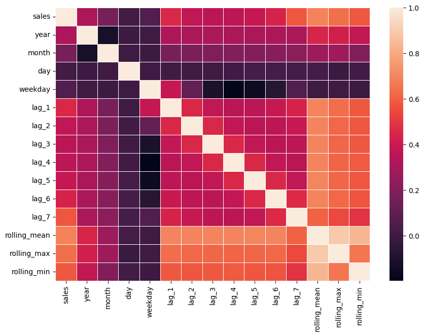

```python
# Correlation matrix with heatmap
corr = reg_train_df.corr()
fig = plt.figure(figsize=(10,7))
_ = sn.heatmap(corr, linewidths=.5)
```

```python
X_train = reg_train_df.drop(['sales'], axis=1)
y_train = reg_train_df['sales'].values

X_test = reg_test_df.drop(['sales'], axis=1)
y_test = reg_test_df['sales'].values

#Univariate SelectKBest class to extract top 5 best features
top_features = SelectKBest(score_func=f_regression, k=5)
fit = top_features.fit(X_train, y_train)
df_scores = pd.DataFrame(fit.scores_)
df_columns = pd.DataFrame(X_train.columns)

#concat two dataframes for better visualization
feature_scores = pd.concat([df_columns, df_scores], axis=1)
feature_scores.columns = ['Feature','Score']  # naming the dataframe columns
print(feature_scores.nlargest(5,'Score'))  # print 5 best features
```

```
         Feature        Score
11  rolling_mean  1577.946956
12   rolling_max  1170.464035
13   rolling_min   888.451268
10         lag_7   860.565955
4          lag_1   449.743115
```

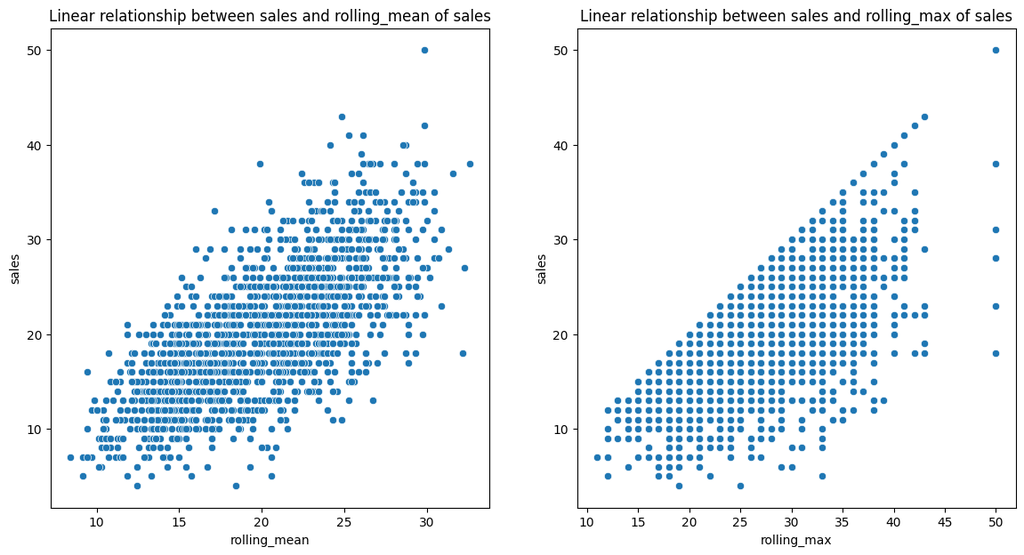

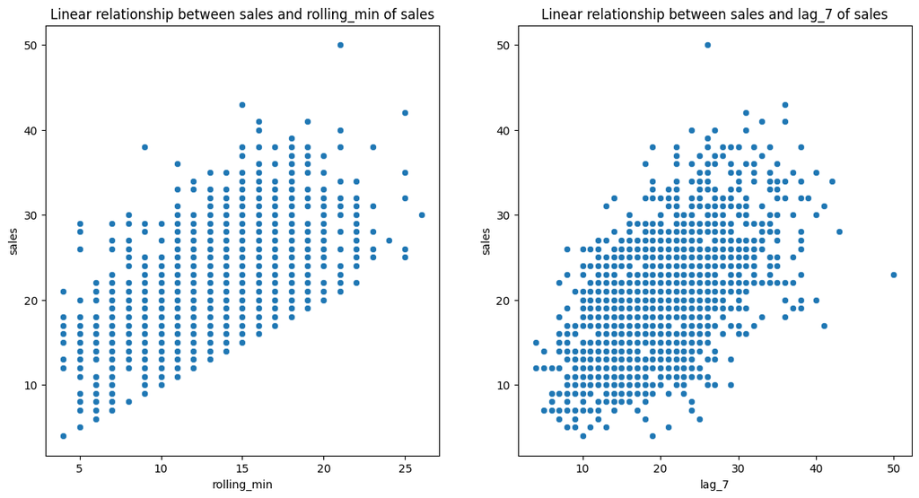

```python
fig, axs = plt.subplots(ncols=2, figsize=(14,7))
sn.scatterplot(x = reg_train_df.rolling_mean, y = reg_train_df.sales, ax=axs[0])
axs[0].set(title='Linear relationship between sales and rolling_mean of sales')
sn.scatterplot(x = reg_train_df.rolling_max, y = reg_train_df.sales, ax=axs[1])
axs[1].set(title='Linear relationship between sales and rolling_max of sales')

fig, axs = plt.subplots(ncols=2, figsize=(14,7))
sn.scatterplot(x = reg_train_df.rolling_min, y = reg_train_df.sales, ax=axs[0])
axs[0].set(title='Linear relationship between sales and rolling_min of sales')
sn.scatterplot(x = reg_train_df.lag_7, y = reg_train_df.sales, ax=axs[1])
_ = axs[1].set(title='Linear relationship between sales and lag_7 of sales')
```

```python
# update X_train, X_test to include top features
X_train = X_train[['rolling_mean', 'rolling_max', 'rolling_min', 'lag_7', 'lag_1']]
X_test = X_test[['rolling_mean', 'rolling_max', 'rolling_min', 'lag_7', 'lag_1']]

# fit model
model = LinearRegression()
model.fit(X_train, y_train)

preds = model.predict(X_test)

errors_df = reg_test_df[['sales']]
errors_df['pred_sales'] = preds
errors_df['errors'] = preds - y_test
errors_df.insert(0, 'model', 'LinearRegression')
```

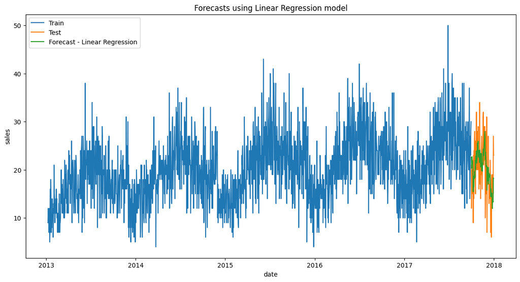

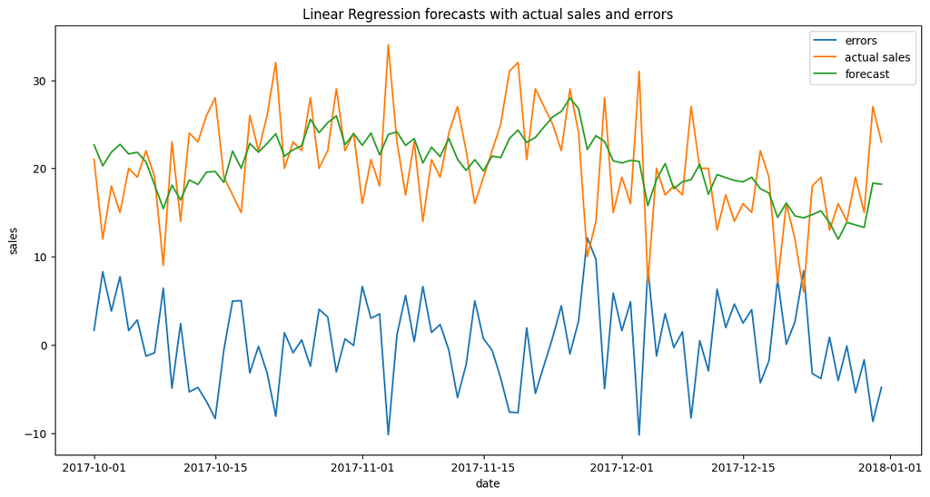

| model | total_sales | total_pred_sales | LR_overall_error | MAE | RMSE | MAPE |
| --- | --- | --- | --- | --- | --- | --- |
| LinearRegression | 1861 | 1882.074831 | 21.074831 | 3.858646 | 4.786183 | 19.075519 |

```python
fig = plt.figure(figsize=(14,7))
plt.plot(reg_train_df.index, reg_train_df['sales'], label='Train')
plt.plot(reg_test_df.index, reg_test_df['sales'], label='Test')
plt.plot(errors_df.index, errors_df['pred_sales'], label='Forecast - Linear Regression')
plt.legend(loc='best')
plt.xlabel('date')
plt.ylabel('sales')
plt.title('Forecasts using Linear Regression model')
plt.show()

fig = plt.figure(figsize=(14,7))
plt.plot(errors_df.index, errors_df.errors, label='errors')
plt.plot(errors_df.index, errors_df.sales, label='actual sales')
plt.plot(errors_df.index, errors_df.pred_sales, label='forecast')
plt.legend(loc='best')
plt.xlabel('date')
plt.ylabel('sales')
plt.title('Linear Regression forecasts with actual sales and errors')
plt.show()

result_df_lr = errors_df.groupby('model').agg(total_sales=('sales', 'sum'),
                                          total_pred_sales=('pred_sales', 'sum'),
                                          LR_overall_error=('errors', 'sum'),
                                          MAE=('errors', mae),
                                          RMSE=('errors', rmse),
                                          MAPE=('errors', mape))
result_df_lr
```